# Harmonised global datasets of wind and solar farm locations and power

Sebastian Dunnett sebdunnett@gmail.com

March 2020

**Scale**: Global  
**Date collected**: Data downloaded from OpenStreetMap March 2020  
**Keywords**: solar, wind, energy, renewable

Funding was provided by Addressing the Valuation of Energy and Nature Together (ADVENT), Grant/Award Number: NE/M019640/1; NERC, and a University of Southampton studentship.

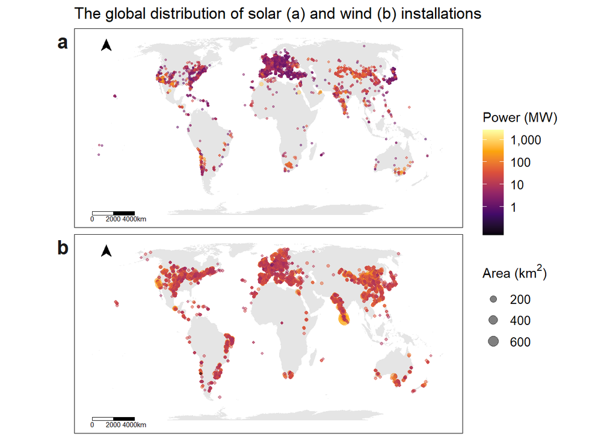

# Data overview

The datasets represent three different formats of the following data:

- Global wind turbines clustered using a neighbourhood distance of 800m;
- Global solar installations clustered using a neighbourhood distance of 400m.

The formats comprise:

1. ESRI geodatabase (*.gdb): proprietary geospatial file format for use with ArcGIS that contains two layers in the same file, one for solar and one for wind;
2. Geopackages (*.gpkg): open source geospatial file format that can work with a variety of software and can store different geometries natively;
3. Comma-delimited files (*.csv): the simplest format, these files represent the centroid of each data record, i.e. point data, as X and Y coordinates in a data table.

Also included is an archive folder, *analysis*, that contains four R scripts and accompanying data used for acquiring and processing the data.

# Sharing and access information

There are no restrictions on the use of these data. The data should be cited as follows:

Dunnett, S. Harmonised global datasets of wind and solar farm locations and power. *figshare*. Dataset. https://doi.org/10.6084/m9.figshare.11310269.v1 (2020)

# Methodology

The full methodology can be found in the accompanying paper<sup>1</sup>.

# Data structure

The datasets are all provided in Eckert IV equal-area projection (EPSG:54012).

**Wind** (*global_wind_2020.**): 33,514 observations  
**Solar** (*global_solar_2020.**): 35,272 observations

Variables

| Name | Detail |
| --- | --- |
| X | X coordinate, Eckert IV projection (.csv only) |
| Y | Y coordinate, Eckert IV projection (.csv only) |
| x_id | unique identifier for data record |
| GID_0 | ISO3 country code |
| panels | number of panels |
| turbines | number of turbines |
| panel.area (p_area for .gdb files) | total panel area in km<sup>2</sup> |
| landscape.area (l_area for .gdb files) | landscape area in km<sup>2</sup> |
| water | binary response indicating whether data record is classified as water using the Global Human Settlement Layer, 1km x 1km resolution |
| urban | binary response indicating whether data record is classified as urban centre using the Global Human Settlement Layer, 1km x 1km resolution |
| power | estimated power capacity in MW |

Please note that, as described in the accompanying paper, these datasets contain ever single observation, *including* sole turbines and solar panels. This is for the sake of completeness; to work with the data, we recommend filtering the data as per the power estimation analysis in the accompanying paper (Methodology): wind installations with more than four turbines and not in a cell identified as urban or water (e.g. `dplyr::filter(turbines>4 & urban!=1 & water!=1)`), and solar panels not in an urban cell and over 1 hectare in panel area.

The *analysis* folder contains four R scripts and seven data files. The package *pacman*, installed at the start of the script with the code `if (!require(pacman)) install.packages('pacman')`, will install the necessary packages not currently installed on your machine and attach them when installed. The scripts perform spatial operations and as such require copies of GDAL and GEOS to be present on your machine.

All file paths are relative, meaning they will only work if the script is running in the correct working directory. This can be set by running the command `setwd(your_path_to_analysis_folder)`.

While these scripts have been written to be as user-friendly as possible, they do require some supervision. For example, *02_osm_processing.R* imports the raw downloaded OSM data (`list.files(path='data', pattern='solar_raw')`) assuming that the user has not changed the file name and location after running the previous script.

The first two scripts take some computing power and time: they were originally performed on a desktop PC with i7-6700 processor and 32GB RAM. The first script relies on continually querying the OSM data servers until a download slot is available as access to OSM data is rate limited. This is entirely dependent on server traffic at the time the script is run; the last run to generate the data presented here took just over four hours. The second script processes large spatial files; the last time this was run it ran for just over half an hour.

R scripts

| Script | Purpose |
| --- | --- |
| 01_osm_data_grab.R | download the latest geospatial data from OSM and save to file |
| 02_osm_processing.R | process the raw OSM data using spatial clustering into indicative ‘farms’ |
| 03_osm_power_models.R | train two power models to estimate power in the processed OSM datasets |
| 04_osm_completeness.R | rerun the Technical Validation described in the accompanying paper (see Methodology above) |

Files in data folder

| File | Description |
| --- | --- |
| deu_re.gpkg | geopackage containing solar and wind location data<sup>2</sup> |
| gadm.gpkg | geopackage containing global administrative areas from [GADM](https://gadm.org/) |
| ghs_2015.tif | raster file of urban centres, Mollweide projection 1km x 1km<sup>3</sup> |
| osm_predictors.csv | table of predictors used for completeness analysis laid out in 04_osm_completeness.R; explanation of variables below |
| ukrepd_0619.csv | June 2019 extract from the UK Renewable Energy Planning Database<sup>4</sup> |
| uswtdb.csv | USGS Wind Turbine Database<sup>5,6</sup> |
| wiki_solar_join.csv | Aspatial data from spatial join of Wiki Solar and the processed OSM solar data; Wiki Solar data<sup>7</sup> given on condition of confidentiality |

Predictor variables included in osm_predictors.csv

| Predictor | Description |
| --- | --- |
| GID_0 | ISO3 country code |
| wind.obs | The number of wind tagged elements in the raw OSM data |
| solar.obs | The number of solar tagged elements in the raw OSM data |
| solar.cap | Reported 2018 solar photovoltaic capacity in MW from the International Renewable Energy Agency (IRENA) |
| wind.cap | Reported 2018 onshore wind capacity in MW from IRENA |
| internetPer1002015 | World Bank IT.NET.USER.P2 indicator 2015 |
| governanceVoice2018 | World Bank Voice & Governance indicator 2018 |
| land | land area in km<sup>2</sup> |
| solar.power | sum of estimated power capacities from processed dataset, MW |
| wind.power | sum of estimated power capacities from processed dataset, MW |

# References

1. Dunnett, S., Sorichetta, A., Taylor, G. & Eigenbrod, F. Harmonised global datasets of wind and solar farm locations and power. *In review* (2020).

2. Eichhorn, M., Scheftelowitz, M., Reichmuth, M., Lorenz, C., Louca, K., Schiffler, A., Keuneke, R., Bauschmann, M., Ponitka, J., Manske, D. & Thrän, D. Spatial Distribution of Wind Turbines, Photovoltaic Field Systems, Bioenergy, and River Hydro Power Plants in Germany. *Data* **4,** 29 (2019).

3. Pesaresi, M., Florczyk, A. J., Schiavina, M., Melchiorri, M. & Maffenini, L. *GHSL Data Package 2019, EUR 29788 EN*. (Publications Office of the European Union, 2019). doi:10.2760/062975

4. BEIS. Renewable Energy Planning Database (REPD). (2019). at <https://data.gov.uk/dataset/a5b0ed13-c960-49ce-b1f6-3a6bbe0db1b7/renewable-energy-planning-database-repd>

5. Hoen, B., Diffendorfer, J., Rand, J., Kramer, L., Garrity, C. & Hunt, H. United States Wind Turbine Database. U.S. Geological Survey, American Wind Energy Association, and Lawrence Berkeley National Laboratory data release: USWTDB V2.2. (2019). doi:10.5066/F7TX3DN0

6. Rand, J. T., Kramer, L. A., Garrity, C. P., Hoen, B. D., Diffendorfer, J. E., Hunt, H. E. & Spears, M. A continuously updated, geospatially rectified database of utility-scale wind turbines in the United States. *Scientific Data* **7,** 15 (2020).

7. Wolfe, P. *Solar Photovoltaic Projects in the Mainstream Power Market*. 240 (Routledge, 2013).